# Predictors of frog survival following translocations - primary analyses

Roland Knapp

The goal of these analyses is to identify predictors of frog survival following translocation. The analyses are conducted in a Bayesian framework using the R package rstanarm.

## Load packages

```r
library(tidyverse)
library(brms)
library(rstanarm)
library(bayesplot)
library(tidybayes)
library(loo)
library(broom.mixed)
library(janitor)
library(patchwork)
library(lubridate)

source("code/classification_summary.R") # When running code chunks directly from within .Rmd (instead of via Makefile), remove "code/".
```

## ANALYSIS 1: Effect of site on survival of all translocated cohorts

### Visualize survival across sites

#### Read in frog translocation dataset

```r
frog_translocation <- read_csv(here::here("data", "clean", "frog_translocation_final.csv")) %>%
  mutate(site_id = as.character(site_id),
         donor = as.character(donor),
         surv = as.integer(if_else(survival < 0.5, 0, 1)))
```

#### Check for null values

```r
frog_translocation %>% summarize(across(everything(), ~ sum(is.na(.))))
```

| site_id | elevation | shore | snow_t | snow_t1 | date | year | day | order | pit_tag_ref | donor | sex | length | weight | bd_load | survival | surv |
| --- | --- | --- | --- | --- | --- | --- | --- | --- | --- | --- | --- | --- | --- | --- | --- | --- |
| 0 | 0 | 0 | 0 | 0 | 0 | 0 | 0 | 0 | 0 | 0 | 0 | 0 | 0 | 12 | 0 | 0 |

- 12 records where bd_load is NA, no other NAs in dataset

#### Retrieve cohort-level frog survival data

```r
files <- fs::dir_ls(here::here("data", "raw", "cmr-analysis", "survival"), glob = "*_cohort.csv")
cohort_survival <- read_csv(files, id = "path") %>%
  mutate(site_id = str_extract(path, "(\\d)+"), .after = path) %>%  # extracts site_id as numeric string from file path
  rename(years_since_intro = years_since_introduction) %>%
  filter(years_since_intro == 1) %>%
  select(site_id, release_date, years_since_intro, median_survival, lo_survival, hi_survival)
rm(files)
```

#### Plot of frog survival for each translocation - grouped by site and arranged by site-specific median survival

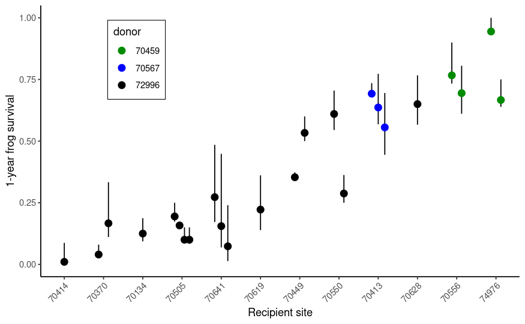

```r
palette1 <- c("green4", "blue", "black")

donors <- frog_translocation %>%
  distinct(site_id, donor)

cohort_survival_plot <- cohort_survival %>%
  mutate(release_year = year(release_date)) %>%
  group_by(site_id) %>%
  summarize(plot_survival = mean(median_survival)) %>%  # create variable by which to order sites for plotting
  arrange(plot_survival) %>%
  mutate(siteid_order = row_number()) %>%
  inner_join(cohort_survival, by = "site_id") %>%
  inner_join(donors, by = "site_id") %>%
  select(-plot_survival) %>%
  ggplot(aes(x = reorder(site_id, siteid_order), y = median_survival, color = donor)) +  # reorder site_id by siteid_order)
      geom_linerange(aes(ymin = lo_survival, ymax = hi_survival), color = "black", width = 0.5, position = position_dodge2(width=0.5)) +
      geom_point(aes(x = reorder(site_id, siteid_order), y = median_survival, color = donor), size = 3, position = position_dodge2(width=0.5)) +
      scale_color_manual(values = palette1) +
      labs(x = "Recipient site", y = "1-year frog survival") +
      theme_classic() +
      theme(
        legend.background = element_rect(color = "black", linewidth = 0.3),
        legend.position = c(0.2, 0.8),
        axis.text.x = element_text(angle = 45, hjust = 1, vjust = 1))
cohort_survival_plot
```

- Strong effect of site/translocation on frog survival.
- Survival is highly variable across sites, but relatively constant within a site.
- Indicates need to include site_id and/or translocation_id as group-level effect(s).

#### Save plot

```r
ggsave(here::here("doc", "manuscript", "figures", "translocation_survival_bysiteid.png"), width = 5, height = 5)
```

#### Plot of frog survival for each translocation - grouped by elevation

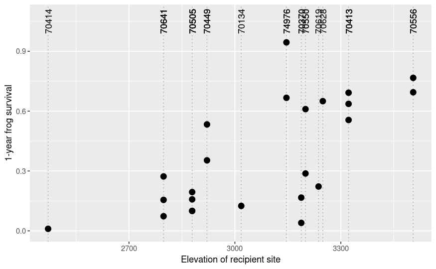

```r
frog_translocation %>%
  distinct(site_id, date, elevation) %>%
  inner_join(cohort_survival, by = c("site_id", "date" = "release_date")) %>%
    ggplot(aes(x = elevation, y = median_survival)) +
      geom_vline(aes(xintercept = elevation), linetype = "dotted", color = "darkgray") +
      geom_point(size = 3) +
      geom_text(aes(label = site_id, x = elevation, y = 1.05), angle = 90) +
      coord_cartesian(ylim = c(0, 1.08)) +
      labs(x = "Elevation of recipient site", y = "1-year frog survival")
```

- Elevation has a clear effect on frog survival, but there is a substantial amount of variation that remains unaccounted for.

### Model survival of frogs from first translocation as predictor of survival in subsequent translocations

- This analysis explores the results shown in the plot created above (frog survival for all translocations grouped by site).

#### Frog translocation dataset for analysis

- Read in data, create variables for analysis, standardize continuous variables.
- arm package used to rescale continuous variables (substract mean, divide by 2 SD), manual centering of binary variables.

```r
d2 <- read_csv(here::here("data", "clean", "frog_translocation_final.csv")) %>%
  select(site_id, year, pit_tag_ref, survival) %>%
  mutate(
    surv = if_else(survival < 0.5, 0, 1),
    across(c(site_id, year), as.factor),
    surv = as.integer(surv))
# Add a descriptive translocation_id
d2 <- d2 %>%
  distinct(site_id, year) %>%
  arrange(site_id, year) %>%
  group_by(site_id) %>%
  mutate(transno = seq_len(n())) %>%
  ungroup(site_id) %>%
  unite(translocation_id, c("site_id", "transno"), remove = FALSE) %>%
  mutate(translocation_id = as.factor(translocation_id)) %>%
  inner_join(d2, by = c("site_id", "year")) %>%
  relocate(translocation_id, .after = site_id) %>%
  relocate(transno, .after = translocation_id)
```

#### Restructure dataset

```r
# Remove sites that received only 1 translocation
d2 <- d2 %>%
  distinct(site_id, transno) %>%
  group_by(site_id) %>%
  mutate(trans_max = max(transno)) %>%
  ungroup(site_id) %>%
  select(-transno) %>%
  filter(trans_max > 1) %>%
  distinct(site_id, trans_max) %>%
  inner_join(d2, by = c("site_id"))

# Create predictor from survival of first translocated cohort
d2 <- d2 %>%
  filter(transno == 1) %>%
  group_by(site_id) %>%
  mutate(survival_trans1 = mean(survival)) %>%
  ungroup(site_id) %>%
  distinct(site_id, survival_trans1) %>%
  mutate(survival_trans1 = round(survival_trans1, 3)) %>%
  inner_join(d2, by = c("site_id")) %>%
  filter(transno != 1) %>%
  relocate(translocation_id, .after = site_id) %>%
  mutate(survival_trans1_z = arm::rescale(survival_trans1), .after = survival_trans1) %>%
  select(-transno, -trans_max)
```

#### Model with non-standardized predictor, no grouping variable

##### Model specification

```r
m2a <- stan_glm(
  surv ~ survival_trans1,
  data = d2,
  family = binomial,
  chains = 4,
  iter = 5000*2,
  cores = 4,
  seed = 84735)
```

```
starting worker pid=10631 on localhost:11139 at 05:02:48.698
starting worker pid=10660 on localhost:11139 at 05:02:48.819
starting worker pid=10689 on localhost:11139 at 05:02:48.940
starting worker pid=10718 on localhost:11139 at 05:02:49.062
```

##### List model variable names

```r
get_variables(m2a)
```

```
[1] "(Intercept)"     "survival_trans1" "accept_stat__"   "stepsize__"      "treedepth__"     "n_leapfrog__"    "divergent__"     "energy__"
```

##### Priors & chain diagnostics

```r
prior_summary(m2a)
```

```
Priors for model 'm2a'
------
Intercept (after predictors centered)
 ~ normal(location = 0, scale = 2.5)

Coefficients
  Specified prior:
    ~ normal(location = 0, scale = 2.5)
  Adjusted prior:
    ~ normal(location = 0, scale = 9)
------
See help('prior_summary.stanreg') for more details
```

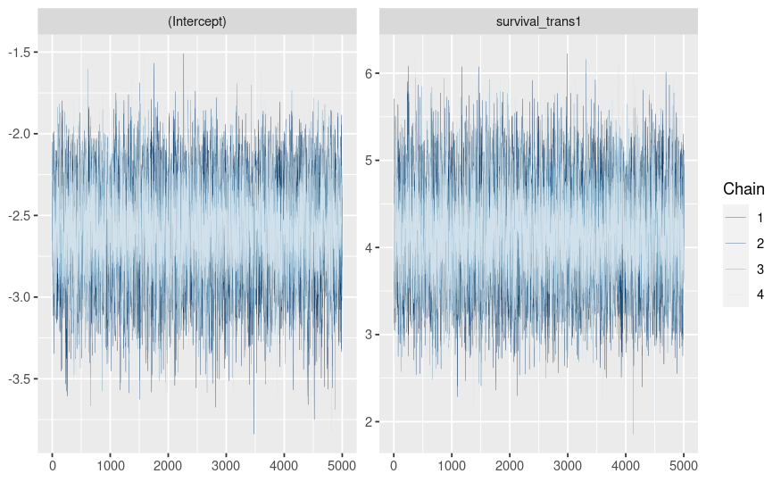

```r
b2 <- c("(Intercept)", "survival_trans1")

mcmc_trace(m2a, size = 0.1, pars = b2)
```

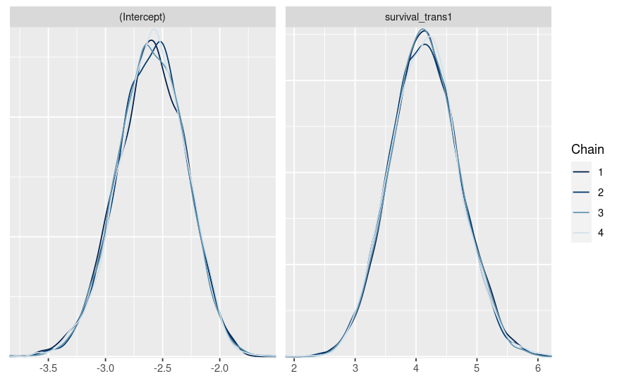

```r
mcmc_dens_overlay(m2a, pars = b2)
```

```r
summary(m2a)
```

```
Model Info:
 function:     stan_glm
 family:       binomial [logit]
 formula:      surv ~ survival_trans1
 algorithm:    sampling
 sample:       20000 (posterior sample size)
 priors:       see help('prior_summary')
 observations: 272
 predictors:   2

Estimates:
                  mean   sd   10%   50%   90%
(Intercept)     -2.6    0.3 -3.0  -2.6  -2.2
survival_trans1  4.1    0.6  3.4   4.1   4.9

Fit Diagnostics:
           mean   sd   10%   50%   90%
mean_PPD 0.3    0.0  0.3   0.3   0.3

The mean_ppd is the sample average posterior predictive distribution of the outcome variable (for details see help('summary.stanreg')).

MCMC diagnostics
                mcse Rhat n_eff
(Intercept)     0.0  1.0   9446
survival_trans1 0.0  1.0  10258
mean_PPD        0.0  1.0  14754
log-posterior   0.0  1.0   8226

For each parameter, mcse is Monte Carlo standard error, n_eff is a crude measure of effective sample size, and Rhat is the potential scale reduction factor on split chains (at convergence Rhat=1).
```

##### Posterior predictive check

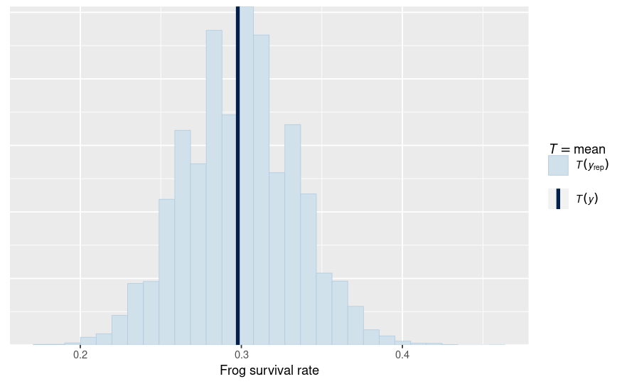

```r
pp_check(m2a, plotfun = "stat") +
    xlab("Frog survival rate")
```

##### Calculate loo

```r
loo_m2a <- loo(m2a, cores = 4, save_psis = TRUE)
print(loo_m2a)
```

```
Computed from 20000 by 272 log-likelihood matrix
```

|  | Estimate | SE |
| --- | --- | --- |
| elpd_loo | -134.6 | 8.9 |
| p_loo | 2.0 | 0.2 |
| looic | 269.2 | 17.8 |

```
------
Monte Carlo SE of elpd_loo is 0.0.

All Pareto k estimates are good (k < 0.5).
See help('pareto-k-diagnostic') for details.
```

##### Posterior analysis

```r
tidy(m2a, conf.int = TRUE, conf.level = 0.90)
```

[output not shown]

#### Model with standardized predictors, no grouping variable

##### Model specification

```r
m2b <- stan_glm(
  surv ~ survival_trans1_z,
  data = d2,
  family = binomial,
  chains = 4,
  iter = 5000*2,
  cores = 4,
  seed = 84735)
```

```
starting worker pid=49341 on localhost:11237 at 10:09:19.507
starting worker pid=49371 on localhost:11237 at 10:09:19.637
starting worker pid=49400 on localhost:11237 at 10:09:19.760
starting worker pid=49429 on localhost:11237 at 10:09:19.880
```

##### List model variable names

```r
get_variables(m2b)
```

##### Priors & chain diagnostics

```r
prior_summary(m2b)

b3 <- c("(Intercept)", "survival_trans1_z")

mcmc_trace(m2b, size = 0.1, pars = b3)
mcmc_dens_overlay(m2b, pars = b3)

summary(m2b)
```

##### Posterior predictive check

```r
pp_check(m2b, plotfun = "stat") +
    xlab("Frog survival rate")
```

##### Calculate loo

```r
loo_m2b <- loo(m2b, cores = 4, save_psis = TRUE)
print(loo_m2b)
```

##### Posterior analysis

```r
tidy(m2b, conf.int = TRUE, conf.level = 0.90)
```

| term | estimate | std.error | conf.low | conf.high |
| --- | --- | --- | --- | --- |
| (Intercept) | -1.065216 | 0.16026 | -1.338363 | -0.8114068 |
| survival_trans1_z | 2.291175 | 0.31297 | 1.790266 | 2.8282451 |

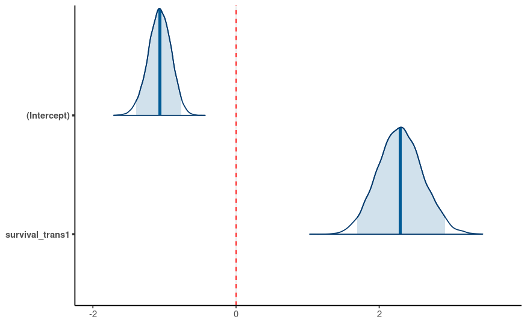

```r
labels_alt <- c("survival_trans1", "(Intercept)")
mcmc_areas(m2b, area_method = "equal height", prob = 0.95, pars = b3) +
  geom_vline(xintercept = 0, color = "red", linetype = "dashed", lwd = 0.5) +
  scale_y_discrete(labels = labels_alt, limits = rev) +
  theme(panel.background = element_rect(fill = "white"),
        axis.line = element_line(color = "black"))
ggsave(here::here("doc", "manuscript", "figures", "mcmc_areas_m2b.png"), bg = "white", width = 7, height = 4)
```

```r
mean(bayes_R2(m2b))
```

```
[1] 0.2454747
```

#### Model with standardized predictors, translocation_id grouping variable

##### Model specification

```r
m2c <- stan_glmer(
  surv ~ survival_trans1_z + (1 | translocation_id),
  data = d2,
  family = binomial,
  chains = 4,
  iter = 5000*2,
  cores = 4,
  seed = 84735)
```

##### Priors & chain diagnostics

```r
prior_summary(m2c)

b3 <- c("(Intercept)", "survival_trans1_z")

mcmc_trace(m2c, size = 0.1, pars = b3)
mcmc_dens_overlay(m2c, pars = b3)

summary(m2c)
```

##### Posterior predictive check

```r
pp_check(m2c, plotfun = "stat") +
    xlab("Frog survival rate")
```

##### Calculate loo

```r
loo_m2c <- loo(m2c, cores = 4, save_psis = TRUE)
print(loo_m2c)
```

##### Posterior analysis

```r
tidy(m2c, conf.int = TRUE, conf.level = 0.90)

mcmc_areas(m2c, area_method = "equal height", prob = 0.95, pars = b3) +
  geom_vline(xintercept = 0, color = "red", linetype = "dashed", lwd = 0.5) +
  ggtitle("Model with standardized predictor & translocation_id as grouping variable",
          "Posterior distributions with medians & 95% uncertainty intervals")

mean(bayes_R2(m2c))

# Frog survival by translocation_id
mcmc_areas_ridges(m2c, regex_pars = "translocation_id") +
  geom_vline(xintercept = 0, color = "red", linetype = "dashed", lwd = 0.5) +
  ggtitle("Frog survival for each translocation_id")
```

#### Model with standardized predictors, site_id grouping variable

##### Model specification

```r
m2d <- stan_glmer(
  surv ~ survival_trans1_z + (1 | site_id),
  data = d2,
  family = binomial,
  chains = 4,
  iter = 5000*2,
  cores = 4,
  seed = 84735)
```

##### Priors & chain diagnostics

```r
prior_summary(m2d)

b3 <- c("(Intercept)", "survival_trans1_z")

mcmc_trace(m2d, size = 0.1, pars = b3)
mcmc_dens_overlay(m2d, pars = b3)

summary(m2d)
```

##### Posterior predictive check

```r
pp_check(m2d, plotfun = "stat") +
    xlab("Frog survival rate")
```

##### Calculate loo

```r
loo_m2d <- loo(m2d, cores = 4, save_psis = TRUE)
print(loo_m2d)
```

##### Posterior analysis

```r
tidy(m2d, conf.int = TRUE, conf.level = 0.90)

mcmc_areas(m2d, area_method = "equal height", prob = 0.95, pars = b3) +
  geom_vline(xintercept = 0, color = "red", linetype = "dashed", lwd = 0.5) +
  ggtitle("Model with standardized predictor & site_id as grouping variable",
          "Posterior distributions with medians & 95% uncertainty intervals")

mean(bayes_R2(m2d))

# Frog survival by site_id
mcmc_areas_ridges(m2d, regex_pars = "site_id") +
  geom_vline(xintercept = 0, color = "red", linetype = "dashed", lwd = 0.5) +
  ggtitle("Frog survival for each site_id")
```

#### Compare 3 models with different grouping structures

```r
loo_compare(loo_m2b, loo_m2c, loo_m2d)
```

#### Posterior classification accuracy of best models

```r
# Generate confusion matrix for m2b
set.seed(84735)
classification_summary(m2b, data = d2, cutoff = 0.5)

# Generate confusion matrix for m2d
set.seed(84735)
classification_summary(m2d, data = d2, cutoff = 0.5)
```

- As expected from loo results, models with and without grouping variable have the same posterior predictive accuracy.

### TO DO

- Validate priors, tune as necessary. Add final priors to model specification (in case the defaults change).

## ANALYSIS 2: Model of site-level and frog-level predictors

### Create frog translocation dataset for analysis

- Read in data, create variables for analysis, standardize continuous variables.
- arm package used to rescale continuous variables (substract mean, divide by 2 SD), manual centering of binary variables.

```r
d1 <- read_csv(here::here("data", "clean", "frog_translocation_final.csv")) %>%
  drop_na(bd_load) %>%  # drop 12 records where bd_load is NA (9 are from 70413)
  mutate(
    first = if_else(order == 1, 1, 0),
    surv = if_else(survival < 0.5, 0, 1),
    male = if_else(sex == "m", 1, 0),
    elev_lo = if_else(elevation < 3020, 1, 0), # using interval defined by cut_interval, n = 2
    elev_z = arm::rescale(elevation),
    snowt_z = arm::rescale(snow_t),
    snowt1_z = arm::rescale(snow_t1),
    day_z = arm::rescale(day),
    length_z = arm::rescale(length),
    bdload_l = log10(bd_load + 1),
    bdload_z = arm::rescale(bdload_l),
    shore_c = shore - mean(shore),
    male_c = male - mean(male),
    elevlo_c = elev_lo - mean(elev_lo),
    first_c = first - mean(first),
    across(c(shore_c, male_c, elevlo_c, first_c), round, 3),
    across(c(site_id, shore_c, first_c, donor, male_c, elevlo_c, year), as.factor),
    surv = as.integer(round(surv)))
```

[output not shown]

```r
# Add a descriptive translocation_id
d1 <- d1 %>%
  distinct(site_id, year) %>%
  arrange(site_id, year) %>%
  group_by(site_id) %>%
  mutate(transno = seq_len(n())) %>%
  ungroup(site_id) %>%
  unite(translocation_id, c("site_id", "transno"), remove = FALSE) %>%
  select(-transno) %>%
  mutate(translocation_id = as.factor(translocation_id)) %>%
  inner_join(d1, by = c("site_id", "year")) %>%
  relocate(translocation_id, .after = site_id)
```

### Check for null values

```r
d1 %>% summarize(across(everything(), ~ sum(is.na(.))))
```

| site_id | translocation_id | year | elevation | shore | snow_t | snow_t1 | date | day | order | pit_tag_ref | donor | sex | length | weight | bd_load | survival | first | surv | male | elev_lo | elev_z | snowt_z | snowt1_z | day_z | length_z | bdload_l | bdload_z | shore_c | male_c | … |
| --- | --- | --- | --- | --- | --- | --- | --- | --- | --- | --- | --- | --- | --- | --- | --- | --- | --- | --- | --- | --- | --- | --- | --- | --- | --- | --- | --- | --- | --- | --- |
| 0 | 0 | 0 | 0 | 0 | 0 | 0 | 0 | 0 | 0 | 0 | 0 | 0 | 0 | 0 | 0 | 0 | 0 | 0 | 0 | 0 | 0 | 0 | 0 | 0 | 0 | 0 | 0 | 0 | 0 | … |

### Model using non-standardized predictors

#### Model specification

```r
m1a <- stan_glm(
  surv ~ length + snow_t + snow_t1 + day + bdload_l + elevation + first + male + donor,
  data = d1,
  family = binomial,
  chains = 4,
  iter = 5000*2,
  cores = 4,
  seed = 84735)
```

#### Explore a flat prior on intercept

```r
m1_flat <- stan_glm(
  surv ~ length + snow_t + snow_t1 + day + bdload_l + elevation + first + male + donor,
  data = d1,
  family = binomial,
  prior_intercept=NULL,
  chains = 4,
  iter = 5000*2,
  cores = 4,
  seed = 84735)

# Confirm that prior is flat
prior_summary(m1_flat)

# Notice that the estimate of the intercept is unchanged between the two models
m1_flat
m1a
```

#### Priors & chain diagnostics

```r
prior_summary(m1a)

mcmc_trace(m1a, size = 0.1)
mcmc_dens_overlay(m1a)

summary(m1a)
```

- mcmc diagnostics all look good.

#### List model variable names

```r
get_variables(m1a)
```

#### Posterior predictive check

```r
pp_check(m1a, plotfun = "stat") +
    xlab("Frog survival rate")
```

- Posterior predictive distribution implied by regression model closely matches original data (based on mean frog survival).

#### Calculate leave-one-out cross-validation (loo)

```r
loo_m1a <- loo(m1a, cores = 4, save_psis = TRUE)
print(loo_m1a)
```

#### Posterior analysis

```r
tidy(m1a, conf.int = TRUE, conf.level = 0.90)

mcmc_intervals(m1a, point_est = "median", prob = 0.80, prob_outer = 0.9) +
  geom_vline(xintercept = 0, color = "red", linetype = "dashed", lwd = 0.5) +  # add 0-line to accentuate default line
  ggtitle("Model with non-standardized predictors only",
          "Posterior distributions with medians & 95% uncertainty intervals")

mcmc_areas(m1a, area_method = "equal height", prob = 0.95) +
  geom_vline(xintercept = 0, color = "red", linetype = "dashed", lwd = 0.5) +
  ggtitle("Model with non-standardized predictors only",
          "Posterior distributions with medians & 95% uncertainty intervals")

mean(bayes_R2(m1a))
```

- Using non-standardized predictors makes plot hard to read due to vastly different scales of predictors.
- Based on 95% uncertainty intervals, important predictors are snow_t1, elevation, first, donor70567, and donor72996.

### Model using standardized predictors

#### Model specification

```r
m1b <- stan_glm(
  surv ~ length_z + snowt_z + snowt1_z + day_z + bdload_z + elev_z + first_c + male_c + donor,
  data = d1,
  family = binomial,
  chains = 4,
  iter = 5000*2,
  cores = 4,
  seed = 84735)
```

#### Priors, chain diagnostics, posterior predictive check

```r
prior_summary(m1b)

mcmc_trace(m1b, size = 0.1)
mcmc_dens_overlay(m1b)

summary(m1b)
```

- mcmc diagnostics all look good.

#### List model variable names

```r
get_variables(m1b)
```

#### Posterior predictive check

```r
pp_check(m1b, plotfun = "stat") +
    xlab("Frog survival rate")
```

- Posterior predictive distribution implied by regression model closely matches original data (based on mean frog survival).

#### Calculate loo

```r
loo_m1b <- loo(m1b, cores = 4, save_psis = TRUE)
print(loo_m1b)
```

#### Posterior analysis

```r
tidy(m1b, conf.int = TRUE, conf.level = 0.90)

mcmc_areas(m1b, area_method = "equal height", prob = 0.95) +
  geom_vline(xintercept = 0, color = "red", linetype = "dashed", lwd = 0.5) +
  ggtitle("Model with standardized predictors only",
          "Posterior distributions with medians & 95% uncertainty intervals")

mean(bayes_R2(m1b))
```

- As expected, using standardized predictors allows easy comparison across predictors. Important predictors are unchanged.
- Based on 95% uncertainty intervals, important predictors are snow_t1, elevation, first, donor70567, and donor72996.

#### Compare models

```r
loo_compare(loo_m1a, loo_m1b)
```

- As expected, models with non-standardized and standardized predictor variables have identical predictive accuracy.

### Model using standardized predictors and site_id grouping variable

#### Model specification

```r
m1c <- stan_glmer(
  surv ~ length_z + snowt_z + snowt1_z + day_z + bdload_z + elev_z + first_c + male_c + donor + (1 | site_id),
  data = d1,
  family = binomial,
  chains = 4,
  iter = 5000*2,
  cores = 4,
  seed = 84735)
```

#### Priors & chain diagnostics

```r
prior_summary(m1c)

b1 <- c("(Intercept)", "length_z", "snowt_z", "snowt1_z", "day_z", "bdload_z", "elev_z", "first_c0.353", "male_c0.548", "donor70567", "donor72996")

mcmc_trace(m1c, size = 0.1, pars = b1)
mcmc_dens_overlay(m1c, pars = b1)

summary(m1c)
```

#### Posterior predictive check

```r
pp_check(m1c, plotfun = "stat") +
    xlab("Frog survival rate")
```

#### Calculate loo

```r
loo_m1c <- loo(m1c, cores = 4, save_psis = TRUE)
print(loo_m1c)
```

#### Posterior analysis

```r
tidy(m1c, conf.int = TRUE, conf.level = 0.90)

mcmc_areas(m1c, area_method = "equal height", prob = 0.95, pars = b1) +
  geom_vline(xintercept = 0, color = "red", linetype = "dashed", lwd = 0.5) +
  ggtitle("Model with standardized predictors & site_id as grouping variable",
          "Posterior distributions with medians & 95% uncertainty intervals")

mean(bayes_R2(m1c))

# Frog survival by site_id
mcmc_areas_ridges(m1c, regex_pars = "site_id") +
  geom_vline(xintercept = 0, color = "red", linetype = "dashed", lwd = 0.5) +
  ggtitle("Frog survival for each recipient site_id")
```

- Based on 95% uncertainty intervals, important predictors reduced to elevation and male.

### Model using standardized predictors and translocation_id grouping variable)

#### Model specification

```r
m1d <- stan_glmer(
  surv ~ length_z + snowt_z + snowt1_z + day_z + bdload_z + elev_z + first_c + male_c + donor + (1 | translocation_id),
  data = d1,
  family = binomial,
  chains = 4,
  iter = 5000*2,
  cores = 4,
  seed = 84735)
```

```
starting worker pid=47866 on localhost:11237 at 09:44:52.215
starting worker pid=47895 on localhost:11237 at 09:44:52.335
starting worker pid=47924 on localhost:11237 at 09:44:52.456
starting worker pid=47953 on localhost:11237 at 09:44:52.578
```

#### Priors & chain diagnostics

```r
prior_summary(m1d)

b1 <- c("(Intercept)", "length_z", "snowt_z", "snowt1_z", "day_z", "bdload_z", "elev_z", "first_c0.353", "male_c0.548", "donor70567", "donor72996")

mcmc_trace(m1d, size = 0.1, pars = b1)
mcmc_dens_overlay(m1d, pars = b1)

summary(m1d)
```

#### Posterior predictive check

```r
pp_check(m1d, plotfun = "stat") +
    xlab("Frog survival rate")
```

#### Calculate loo

```r
loo_m1d <- loo(m1d, cores = 4, save_psis = TRUE)
print(loo_m1d)
```

#### Posterior analysis

```r
tidy(m1d, conf.int = TRUE, conf.level = 0.95)
```

| term | estimate | std.error | conf.low | conf.high |
| --- | --- | --- | --- | --- |
| (Intercept) | 0.281791899 | 0.6794133 | -1.1387957 | 1.6765011 |
| length_z | 0.002911989 | 0.2335191 | -0.4576745 | 0.4627818 |
| snowt_z | 0.016431429 | 0.5587222 | -1.1653269 | 1.1630932 |
| snowt1_z | -1.186052029 | 0.5331704 | -2.2735343 | -0.1033852 |
| day_z | 0.098659045 | 0.5149599 | -0.9930796 | 1.1796542 |
| bdload_z | -0.227553444 | 0.2075879 | -0.6367478 | 0.1794658 |
| elev_z | 1.602791535 | 0.6144519 | 0.3879607 | 2.9487432 |
| first_c0.353 | 0.496924259 | 0.4583293 | -0.4599191 | 1.4433759 |
| male_c0.548 | 0.330792635 | 0.1993556 | -0.0539348 | 0.7162665 |
| donor70567 | -1.276717276 | 0.8091455 | -3.0042998 | 0.4409461 |

[output cut: 1 more lines]

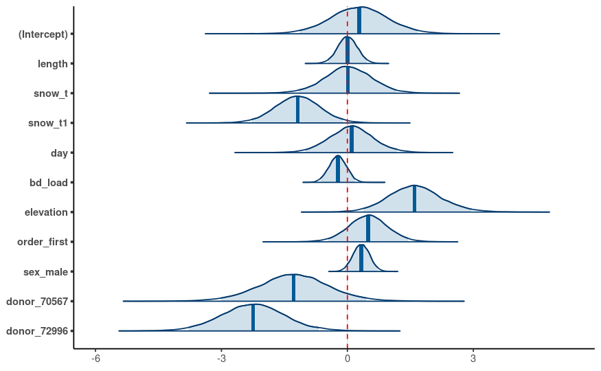

```r
labels_alt <- c("donor_72996", "donor_70567", "sex_male", "order_first", "elevation", "bd_load", "day", "snow_t1", "snow_t", "length", "(Intercept)")
mcmc_areas(m1d, area_method = "equal height", prob = 0.95, pars = b1) +
  geom_vline(xintercept = 0, color = "red", linetype = "dashed", lwd = 0.5) +
  scale_y_discrete(labels = labels_alt, limits = rev) +
  theme(panel.background = element_rect(fill = "white"),
        axis.line = element_line(color = "black"))
ggsave(here::here("doc", "manuscript", "figures", "mcmc_areas_m1d.png"), width = 5, height = 5)
```

```r
mean(bayes_R2(m1d))
```

```
[1] 0.322301
```

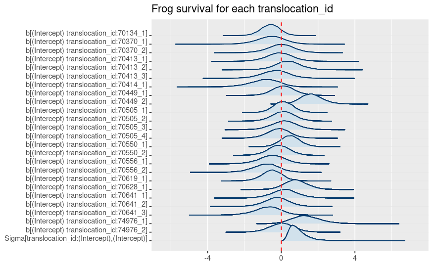

```r
# Frog survival by translocation_id
mcmc_areas_ridges(m1d, regex_pars = "translocation_id") +
  geom_vline(xintercept = 0, color = "red", linetype = "dashed", lwd = 0.5) +
  ggtitle("Frog survival for each translocation_id")
```

### Model using standardized predictors and 2 grouping variables: translocation_id nested within site_id)

#### Model specification

```r
m1e <- stan_glmer(
  surv ~ length_z + snowt_z + snowt1_z + day_z + bdload_z + elev_z + first_c + male_c + donor + (1 | translocation_id) + (1 | site_id),
  data = d1,
  family = binomial,
  chains = 4,
  iter = 5000*2,
  cores = 4,
  seed = 84735)
```

#### Priors & chain diagnostics

```r
prior_summary(m1e)

b1 <- c("(Intercept)", "length_z", "snowt_z", "snowt1_z", "day_z", "bdload_z", "elev_z", "first_c0.353", "male_c0.548", "donor70567", "donor72996")

mcmc_trace(m1e, size = 0.1, pars = b1)
mcmc_dens_overlay(m1e, pars = b1)

summary(m1e)
```

#### Posterior predictive check

```r
pp_check(m1e, plotfun = "stat") +
    xlab("Frog survival rate")
```

#### Calculate loo

```r
loo_m1e <- loo(m1e, cores = 4, save_psis = TRUE)
print(loo_m1e)
```

#### Posterior analysis

```r
tidy(m1e, conf.int = TRUE, conf.level = 0.90)

mcmc_areas(m1e, area_method = "equal height", prob = 0.95, pars = b1) +
  geom_vline(xintercept = 0, color = "red", linetype = "dashed", lwd = 0.5) +
  ggtitle("Model with standardized predictors & translocation_id/site_id as grouping variables",
          "Posterior distributions with medians & 95% uncertainty intervals")

mean(bayes_R2(m1e))

# Frog survival by translocation_id
mcmc_areas_ridges(m1e, regex_pars = ("translocation_id")) +
  geom_vline(xintercept = 0, color = "red", linetype = "dashed", lwd = 0.5) +
  ggtitle("Frog survival for each translocation_id")

# Frog survival by site_id
mcmc_areas_ridges(m1e, regex_pars = ("site_id")) +
  geom_vline(xintercept = 0, color = "red", linetype = "dashed", lwd = 0.5) +
  ggtitle("Frog survival for each translocation_id")
```

### Compare 4 models with different grouping structures

```r
loo_compare(loo_m1b, loo_m1c, loo_m1d, loo_m1e)
```

### Additional analysis of model m1d

#### Posterior classification accuracy

```r
# Posterior predictive models for each frog in dataset
set.seed(84735)
survival_predict_1 <- posterior_predict(m1d, newdata = d1)

# Classify frog survival based on mean predicted survival probability
survival_predict_2 <- d1 %>%
  mutate(survival_prob = colMeans(survival_predict_1),
         survival_class = as.numeric(survival_prob >= 0.5)) %>%
  select(site_id, translocation_id, year, snowt1_z, elev_z, male_c, donor, surv, survival_prob, survival_class)

# Generate confusion matrix and calculate accuracy
survival_predict_2 %>%
  tabyl(surv, survival_class) %>%
  adorn_totals(c("row", "col"))

(471 + 138)/767 # overall_accuracy
471/533 # true negative rate (specificity)
138/234 # true positive rate (sensitivity)

# Generate confusion matrix using function
set.seed(84735)
classification_summary(m1d, data = d1, cutoff = 0.5)
```

- Sensitivity or “true positive rate” measures the proportion of Y = 1 observations that are accurately classified.
- Specificity or “true negative rate” measures the proportion of Y = 0 observations that are accurately classified (i.e., proportion of frogs correctly identified as not surviving).

### Reduced model from m1d

#### Create reduced model containing only important predictors for subsequent analyses

```r
m1d_reduce <- stan_glmer(
  surv ~ snowt1_z + elev_z + male_c + donor + (1 | translocation_id),
  data = d1,
  family = binomial,
  chains = 4,
  iter = 5000*2,
  cores = 4,
  seed = 84735)
```

```
starting worker pid=57549 on localhost:11698 at 09:23:45.722
starting worker pid=57579 on localhost:11698 at 09:23:45.849
starting worker pid=57609 on localhost:11698 at 09:23:45.971
starting worker pid=57639 on localhost:11698 at 09:23:46.093
```

#### Posterior analysis

```r
tidy(m1d_reduce, conf.int = TRUE, conf.level = 0.95)

b2 <- c("(Intercept)", "snowt1_z", "elev_z", "male_c0.548", "donor70567", "donor72996")

mcmc_areas(m1d_reduce, area_method = "equal height", prob = 0.95, pars = b2) +
  geom_vline(xintercept = 0, color = "red", linetype = "dashed", lwd = 0.5) +
  ggtitle("Reduced model with standardized predictors & translocation_id as grouping variable",
          "Posterior distributions with medians & 95% uncertainty intervals")
```

#### Confirm that fit of reduced model is comparable to full model

```r
loo_m1d_reduce <- loo(m1d, cores = 4, save_psis = TRUE)
print(loo_m1d)

loo_compare(loo_m1d, loo_m1d_reduce)
```

#### Simulate and plot posterior predictive models & observations

##### Reduced model with translocation_id as grouping variable

```r
m1d_group_means <- d1 %>%
  group_by(translocation_id) %>%
  summarize(count = n(), psurv = mean(surv), elev_z = mean(elev_z), snowt1_z = mean(snowt1_z)) %>%
  mutate(
    male_c = as.factor(0.548),
    donor = case_when(
      str_detect(translocation_id, "74976") | str_detect(translocation_id, "70556") ~ "70459",
      str_detect(translocation_id, "70413") ~ "70567",
      TRUE ~ "72996")) %>%
  arrange(psurv)  # to arrange plot values/labels by psurv

predictions_m1d <- posterior_epred(m1d_reduce, newdata = m1d_group_means)

ppc_intervals(
  y = m1d_group_means$psurv,
  yrep = predictions_m1d,
  prob = 0.8,
  prob_outer = 0.9) +
ggplot2::scale_x_continuous(
  labels = m1d_group_means$translocation_id,
  breaks = 1:nrow(m1d_group_means)) +
  xaxis_text(angle = 90, vjust = 0.5) +
xlab("Translocation_id")
```

- Model does a good job of predicting survival based on group-level and individual-level characteristics.
- Predicted survival is based on assumption that only males are included. Run another set of models for females?

##### Reduced model without grouping variable

To explore how addition of grouping variable affected predictions, especially that for 70370 and 70550.

```r
m1d_reduce_nogroup <- stan_glm(
  surv ~ snowt1_z + elev_z + male_c + donor,
  data = d1,
  family = binomial,
  chains = 4,
  iter = 5000*2,
  cores = 4,
  seed = 84735)

m1d_group_means <- d1 %>%
  group_by(translocation_id) %>%
  summarize(count = n(), psurv = mean(surv), elev_z = mean(elev_z), snowt1_z = mean(snowt1_z)) %>%
  mutate(
    male_c = as.factor(0.548),
    donor = case_when(
      str_detect(translocation_id, "74976") | str_detect(translocation_id, "70556") ~ "70459",
      str_detect(translocation_id, "70413") ~ "70567",
      TRUE ~ "72996")) %>%
  arrange(psurv)  # to arrange plot values/labels by psurv

predictions_m1d_nogroup <- posterior_epred(m1d_reduce_nogroup, newdata = m1d_group_means)

ppc_intervals(
  y = m1d_group_means$psurv,
  yrep = predictions_m1d_nogroup,
  prob = 0.8,
  prob_outer = 0.9) +
ggplot2::scale_x_continuous(
  labels = m1d_group_means$translocation_id,
  breaks = 1:nrow(m1d_group_means)) +
  xaxis_text(angle = 90, vjust = 0.5) +
xlab("Translocation_id")
```

##### Values of important predictors for translocations of interest

```r
d1 %>%
  filter(site_id == "70370" | site_id == "70550") %>%
  distinct(translocation_id, elevation, snow_t1, donor)
```

- This helps to explain the low predicted survival at 70370 (both translocations), and high versus low predicted survival at 70550 for 1st and 2nd translocations, respectively.
  - Without translocation_id as group-level effect, survival from two translocations at 70550 are not predicted well and both are predicted to have similar (and moderate) frog survival (based on high elevation, low snow_t1, and donor = 72996 for both translocations). Therefore, the group-level effect is responsible for good prediction of survival at this site.
  - Low survival at 70370 in both translocations is predicted relatively well by models with and without group-level effect. Low predicted survival can be attributed to high snow_t1 and donor = 72996 in both translocations (although high elevation of site should have positive effect).

#### Plot posterior plausible relationships between each predictor and the probability of frog survival (conditional effects)

##### Effect of elevation

```r
d1_elevz <- d1 %>%
  mutate(snowt1_z = mean(snowt1_z),
         male_c = recode(male_c, "-0.452" = "0.548"),
         donor = recode(donor, "70567" = "70459", "72996" = "70459"))

d1_elevz %>% distinct(snowt1_z, male_c, donor) # ensure variables were set to correct values
```

| snowt1_z | male_c | donor |
| --- | --- | --- |
| 4.028998e-17 | 0.548 | 70459 |

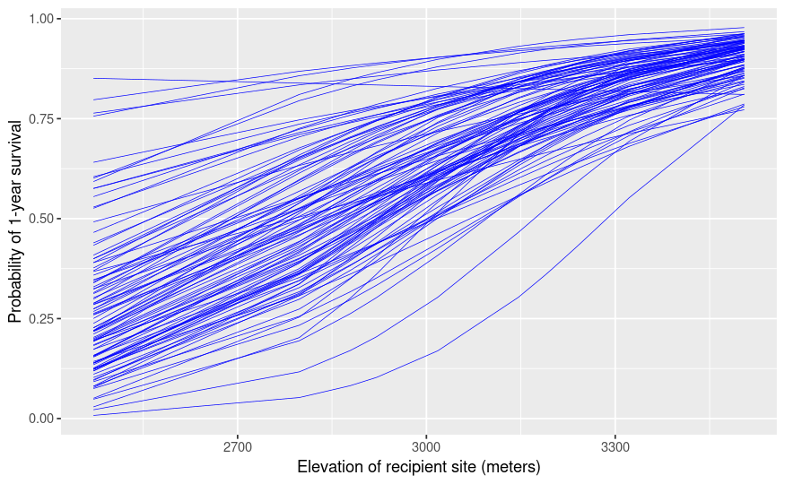

```r
# use untransformed predictor (elevation) to make plot easier to interpret
d1_elevz %>%
  select(site_id, translocation_id, snowt1_z, elev_z, elevation, male_c, donor, surv) %>%
  add_epred_draws(m1d_reduce, ndraws = 100, re_formula = NA) %>%
  ggplot(aes(x = elevation, y = surv)) +  #   "ggplot(aes(x = (elev_z * 2*sd_elev) + mean_elev, y = surv)) +" gives identical result
          geom_line(aes(y = .epred, group = .draw), color = "blue", linewidth = 0.2, alpha = 1) +
        # geom_point(aes(y = .epred)) +
          labs(x = "Elevation of recipient site (meters)", y = "Probability of 1-year survival")
```

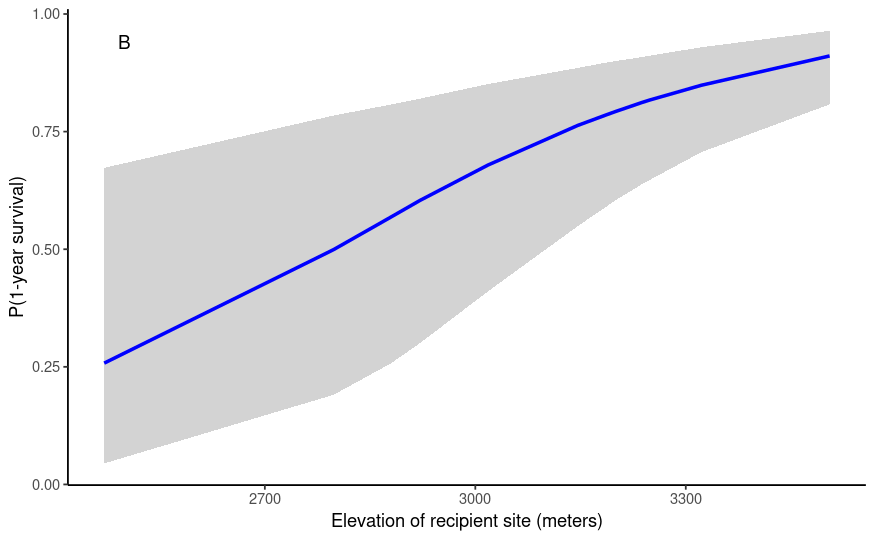

```r
# Plot with confidence bands
alpha = 1 - 0.95

p_elev <- d1_elevz %>%
  select(site_id, translocation_id, snowt1_z, elev_z, elevation, male_c, donor, surv) %>%
  add_epred_draws(m1d_reduce, ndraws = 1000, re_formula = NA) %>%
  group_by(elevation) %>%
  summarise(lower = quantile(.epred, alpha),
            upper = quantile(.epred, 1 - alpha),
            median = quantile(.epred, 0.5)) %>%
  ggplot(aes(x = elevation)) +
          geom_ribbon(aes(ymin = lower, ymax = upper), fill= "lightgray", alpha = 1) +
          geom_line(aes(y = median), color = "blue", linewidth = 1, alpha = 1) +
          labs(x = "Elevation of recipient site (meters)", y = "P(1-year survival)") +
          annotate(geom = "text", x = 2500, y = 0.94, label = "B", size = 4) +
          theme_classic()

p_elev
```

##### Effect of winter severity in year t1

```r
d1_snowt1z <- d1 %>%
  mutate(elev_z = mean(elev_z),
         male_c = recode(male_c, "-0.452" = "0.548"),
         donor = recode(donor, "70567" = "70459", "72996" = "70459"))

d1_snowt1z %>% distinct(elev_z, male_c, donor) # ensure variables were set to correct values
```

| elev_z | male_c | donor |
| --- | --- | --- |
| 2.372734e-16 | 0.548 | 70459 |

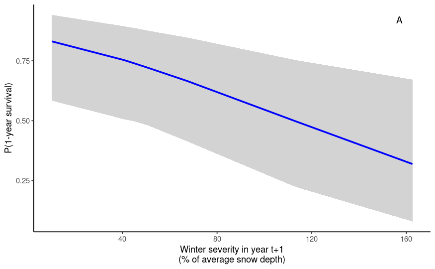

```r
alpha = 1 - 0.95

p_snowt1 <- d1_snowt1z %>%
  select(site_id, translocation_id, snowt1_z, snow_t1, elev_z, male_c, donor, surv) %>%
  add_epred_draws(m1d_reduce, ndraws = 1000, re_formula = NA) %>%
  group_by(snow_t1) %>%
  summarise(lower = quantile(.epred, alpha),
            upper = quantile(.epred, 1 - alpha),
            median = quantile(.epred, 0.5)) %>%
  ggplot(aes(x = snow_t1)) +
          geom_ribbon(aes(ymin = lower, ymax = upper), fill = "lightgray", alpha = 1) +
          geom_line(aes(y = median), color = "blue", linewidth = 1, alpha = 1) +
          labs(x = "Winter severity in year t+1\n(% of average snow depth)", y = "P(1-year survival)") +
          annotate(geom = "text", x = 157, y = 0.92, label = "A", size = 4) +
          theme_classic()

p_snowt1
```

##### Effect of sex

```r
d1_malec <- d1 %>%
  mutate(elev_z = mean(elev_z),
         snowt1_z = mean(snowt1_z),
         donor = recode(donor, "70567" = "70459", "72996" = "70459"))

d1_malec %>% distinct(elev_z, snowt1_z, donor) # ensure variables were set to correct values
```

| elev_z | snowt1_z | donor |
| --- | --- | --- |
| 2.372734e-16 | 4.028998e-17 | 70459 |

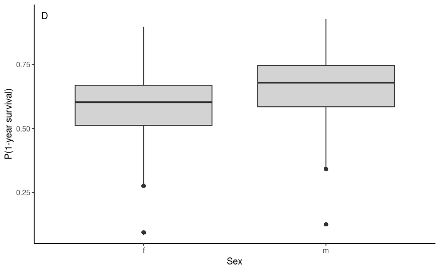

```r
p_sex <- d1_malec %>%
  select(site_id, translocation_id, snowt1_z, elev_z, male_c, sex, donor, surv) %>%
  add_epred_draws(m1d_reduce, ndraws = 100, re_formula = NA) %>%
  ggplot(aes(x = male, y = surv)) +
    geom_boxplot(aes(y = .epred, x = sex), fill = "lightgray") +
    labs(x = "Sex", y = "P(1-year survival)") +
    annotate(geom = "text", x = 0.4, y = 0.94, hjust = -1, label = "D", size = 4) +
    theme_classic()

p_sex
```

##### Effect of donor

```r
d1_donor <- d1 %>%
  mutate(elev_z = mean(elev_z),
         snowt1_z = mean(snowt1_z),
         male_c = recode(male_c, "-0.452" = "0.548"))

d1_donor %>% distinct(elev_z, snowt1_z, male_c) # ensure variables were set to correct values
```

| elev_z | snowt1_z | male_c |
| --- | --- | --- |
| 2.372734e-16 | 4.028998e-17 | 0.548 |

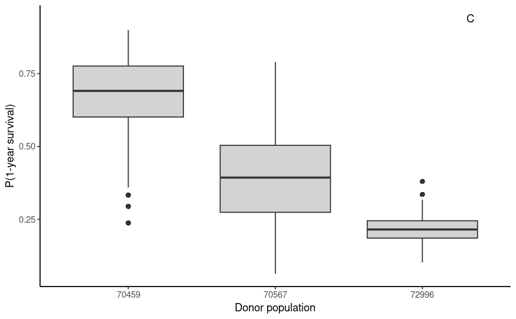

```r
p_donor <- d1_donor %>%
  select(site_id, translocation_id, snowt1_z, elev_z, male_c, donor, surv) %>%
  add_epred_draws(m1d_reduce, ndraws = 100, re_formula = NA) %>%
  ggplot(aes(x = donor, y = surv)) +
    geom_boxplot(aes(y = .epred, x = donor), fill = "lightgray") +
    labs(x = "Donor population", y = "P(1-year survival)") +
    annotate(geom = "text", x = 3.3, y = 0.94, hjust = 0, label = "C", size = 4) +
    theme_classic()

p_donor
```

##### Joint effects of elevation and sex

```r
d1_elevz_malec <- d1 %>%
  mutate(snowt1_z = mean(snowt1_z),
         donor = recode(donor, "70567" = "70459", "72996" = "70459"))

d1_elevz_malec %>% distinct(snowt1_z, donor) # ensure variables were set to correct values

# plot individual draws grouped by sex
pal <- c("#0d0887", "#f89540")
d1_elevz_malec %>%
  select(site_id, translocation_id, snowt1_z, elev_z, elevation, male_c, sex, donor, surv) %>%
  add_epred_draws(m1d_reduce, ndraws = 100, re_formula = NA) %>%
  ggplot(aes(x = elevation, y = surv, color = sex)) +
          geom_line(aes(y = .epred, group = paste(sex, .draw)), linewidth = 0.4, alpha = 0.5) +
          labs(x = "Elevation of recipient site (meters)", y = "Probability of 1-year survival") +
          scale_color_manual(values = pal) +
          theme_classic()

# plot medians and uncertainty ribbons grouped by sex
p_elevsex <- d1_elevz_malec %>%
  select(site_id, translocation_id, snowt1_z, elev_z, elevation, male_c, sex, donor, surv) %>%
  add_epred_draws(m1d_reduce, ndraws = 1000, re_formula = NA) %>%
  group_by(elevation, sex) %>%
  summarise(lower = quantile(.epred, alpha),
            upper = quantile(.epred, 1 - alpha),
            median = quantile(.epred, 0.5)) %>%
  ggplot(aes(x = elevation, group = sex)) +
          geom_ribbon(aes(ymin = lower, ymax = upper, fill = sex), alpha = 0.2, linetype = 0) +
          geom_line(aes(y = median, color = sex), linewidth = 1, alpha = 1) +
          labs(x = "Elevation of recipient site (meters)", y = "Probability of 1-year survival") +
          scale_color_manual(values = pal) +
          scale_fill_manual(values = pal) +
          theme_classic()

p_elevsex
```

##### Create multi-panel conditional effects figure

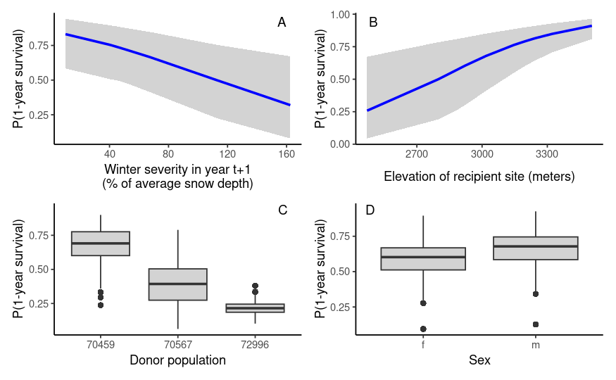

```r
cond_effects_plot <- (p_snowt1 | p_elev) / (p_donor | p_sex)
cond_effects_plot
```

##### Save plot

```r
ggsave(here::here("doc", "manuscript", "figures", "cond_effects_plot.png"), width = 7, height = 4)
```

#### For comparison, fit model using brms and conditional_effects function to plot variable-specific effects

##### Fit model

```r
m1d_reduce_brms <- brm(
  surv ~ snowt1_z + elev_z + male_c + donor + (1 | translocation_id),
  data = d1,
  family = bernoulli(),
  chains = 4,
  iter = 5000*2,
  cores = 4,
  seed = 84735)
```

##### Plot conditional effects

```r
plot(conditional_effects(m1d_reduce_brms, spaghetti = TRUE, mean = TRUE, ndraws = 100), ask = FALSE)
```